# ProjectEDA_Report

# Introduction

Among economists, there are debates about which system was more efficient and fair, the Bretton Woods system existing from 1944 to 1971, or the post-Bretton Woods system, existing since the collapse of the former.

To the extent that the available data allows, I will try to compare these two periods. Some economists believe that the post-Bretton Woods system collapsed (or was significantly disrupted) with the onset of the Global Financial Crisis (GFC) in 2008. Therefore, I will also compare data for the periods 1971-2008 and from 2009 to today (or until the data ends).

My analyses will be based on the following indicators:

- year-on-year GDP growth
- investment as a % of GDP
- year-on-year inflation
- trade balance
- Gini coefficient
- unemployment
- hours worked per week
- life expectancy

All the data I use comes from gapminder.org.

Libraries I will use:

```r
library(ggplot2)
library(tidyverse)
library(zoo)
```

Loading CSV files and an initial look at them (all data comes from gapminder.org).

```r
setwd("ProjektEDA/project_data")

# Loading data
aged_15plus_unemployment <- read.csv("aged_15plus_unemployment_rate_percent.csv")
gdp_growth <- read.csv("gdp_total_yearly_growth.csv")
gini <- read.csv("gini.csv")
inflation <- read.csv("inflation_annual_percent.csv")
investment <- read.csv("investments_percent_of_gdp.csv")
life_expectancy <- read.csv("lex.csv")
trade_balance <- read.csv("trade_balance_percent_of_gdp.csv")
working_hours <- read.csv("working_hours_per_week.csv")

# Initial data analysis
head(aged_15plus_unemployment)
```

```
##                country X1947 X1948 X1949 X1950 X1951 X1952 X1953 X1954 X1955
## 1                Aruba    NA    NA    NA    NA    NA    NA    NA    NA    NA
## 2          Afghanistan    NA    NA    NA    NA    NA    NA    NA    NA    NA
## 3               Angola    NA    NA    NA    NA    NA    NA    NA    NA    NA
## 4             Anguilla    NA    NA    NA    NA    NA    NA    NA    NA    NA
## 5              Albania    NA    NA    NA    NA    NA    NA    NA    NA    NA
## 6 Netherlands Antilles    NA    NA    NA    NA    NA    NA    NA    NA    NA
##   X1956 X1957 X1958 X1959 X1960 X1961 X1962 X1963 X1964 X1965 X1966 X1967 X1968
## 1    NA    NA    NA    NA    NA    NA    NA    NA    NA    NA    NA    NA    NA
## 2    NA    NA    NA    NA    NA    NA    NA    NA    NA    NA    NA    NA    NA
## 3    NA    NA    NA    NA    NA    NA    NA    NA    NA    NA    NA    NA    NA
## 4    NA    NA    NA    NA    NA    NA    NA    NA    NA    NA    NA    NA    NA
## 5    NA    NA    NA    NA    NA    NA    NA    NA    NA    NA    NA    NA    NA
## 6    NA    NA    NA    NA    NA    NA    NA    NA    NA    NA    NA    NA    NA
##   X1969 X1970 X1971 X1972 X1973 X1974 X1975 X1976 X1977 X1978 X1979 X1980 X1981
```

[output cut: 27 more lines]

```r
head(gdp_growth)
```

```
##       country X1801 X1802 X1803 X1804 X1805 X1806 X1807 X1808 X1809 X1810 X1811
## 1       Aruba 0.000 0.000 0.000 0.000 0.000 0.000 0.000 0.000 0.000 0.000 0.000
## 2 Afghanistan 0.000 0.000 0.000 0.000 0.000 0.000 0.000 0.000 0.000 0.000 0.000
## 3      Angola 0.425 0.425 0.425 0.425 0.425 0.425 0.425 0.425 0.425 0.425 0.425
## 4    Anguilla 0.000 0.000 0.000 0.000 0.000 0.000 0.000 0.000 0.000 0.000 0.000
## 5     Albania 0.418 0.418 0.418 0.418 0.418 0.418 0.418 0.418 0.418 0.418 0.418
## 6     Andorra 0.166 0.166 0.166 0.166 0.166 0.166 0.166 0.166 0.166 0.166 0.166
##   X1812 X1813 X1814 X1815 X1816 X1817 X1818 X1819 X1820 X1821 X1822 X1823 X1824
## 1 0.000 0.000 0.000 0.000 0.000 0.000 0.000 0.000 0.000 1.190 1.190 1.190 1.190
## 2 0.000 0.000 0.000 0.000 0.000 0.000 0.000 0.000 0.000 0.826 0.826 0.826 0.826
## 3 0.425 0.425 0.425 0.425 0.425 0.425 0.425 0.425 0.425 1.160 1.160 1.160 1.160
## 4 0.000 0.000 0.000 0.000 0.000 0.000 0.000 0.000 0.000 1.410 1.350 1.400 1.390
## 5 0.418 0.418 0.418 0.418 0.418 0.418 0.418 0.418 0.418 0.664 0.664 0.664 0.664
## 6 0.166 0.166 0.166 0.166 0.166 0.166 0.166 0.166 0.166 1.820 1.860 1.810 1.850
##   X1825 X1826 X1827 X1828 X1829 X1830 X1831 X1832 X1833 X1834 X1835 X1836 X1837
```

[output cut: 111 more lines]

As seen from the initial analysis, the files are not in the so-called long format, which will need to be considered in the further part of the code (in the final R-Markdown file, I only look at 2 files for better readability, all other files are in a similar format).

The analysis will be conducted only for some countries, I chose those whose currency was pegged to the dollar during the Bretton Woods system. These countries are: United Kingdom, France, Germany, Japan, Italy, Switzerland, Netherlands, Belgium, Finland, Denmark, Greece, Spain.

Below, I filter the previously loaded data to those concerning only countries from this group.

```r
analized_countries <- c("UK", "France", "Germany", "Italy", "Japan", "Switzerland",
                        "Netherlands", "Belgium", "Finland", "Denmark", "Greece", "Spain")


# Limiting data to analyzed countries
aged_15plus_unemployment_analized_countries <- aged_15plus_unemployment %>% filter(country %in% analized_countries)
gdp_growth_analized_countries <- gdp_growth %>% filter(country %in% analized_countries)
gini_analized_countries <- gini %>% filter(country %in% analized_countries)
inflation_analized_countries <- inflation %>% filter(country %in% analized_countries)
investment_analized_countries <- investment %>% filter(country %in% analized_countries)
life_expectancy_analized_countries <- life_expectancy %>% filter(country %in% analized_countries)
trade_balance_analized_countries <- trade_balance %>% filter(country %in% analized_countries)
working_hours_analized_countries <- working_hours %>% filter(country %in% analized_countries)
```

# Year-on-year GDP Growth

First, we will analyze the year-on-year GDP growth. To do this, we need to convert the data to the so-called long format.

```r
# Data conversion to long format
gdp_growth_analized_countries_long <- gdp_growth_analized_countries %>%
  pivot_longer(cols = -country, names_to = "Year", values_to = "GDP_growth") %>%
  mutate(Year = as.numeric(gsub("^X", "", Year)))
```

Now, let’s plot a graph illustrating the year-on-year GDP growth for all available years

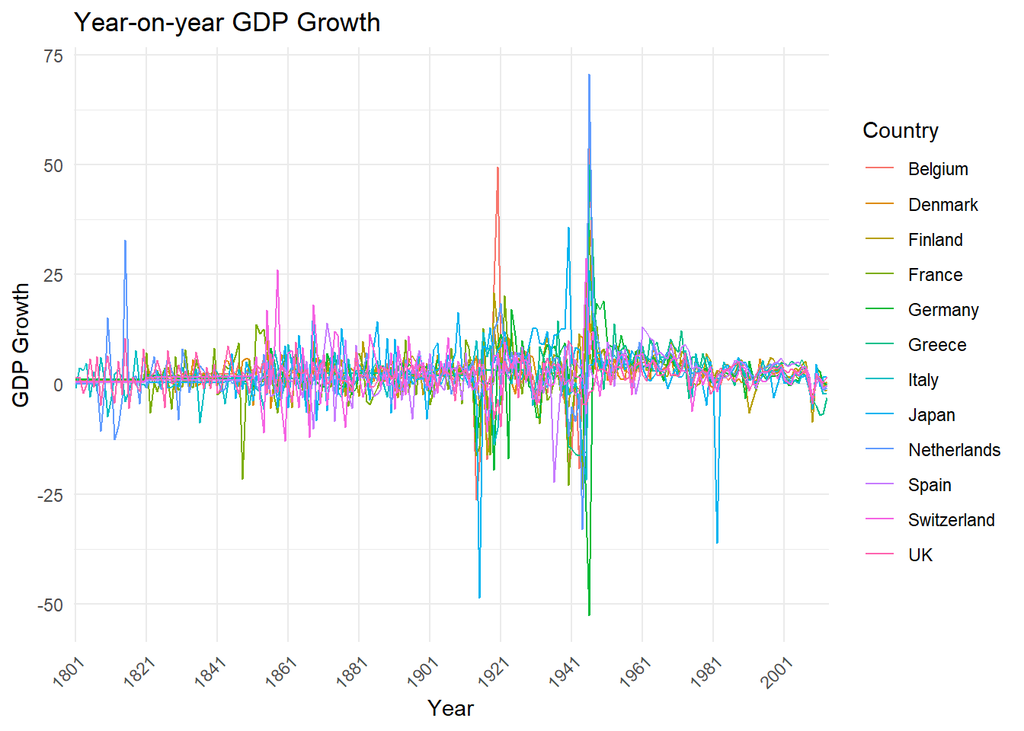

```r
# Line chart for annual GDP growth of the analyzed countries
ggplot(gdp_growth_analized_countries_long, aes(x = as.factor(Year), y = GDP_growth, color = country, group = country)) +
  geom_line() +
  labs(title = "Year-on-year GDP Growth",
       y = "GDP Growth",
       x = "Year",
       color = "Country") +
  theme_minimal() +
  theme(axis.text.x = element_text(angle = 45, hjust = 1)) +
  scale_x_discrete(breaks = seq(min(gdp_growth_analized_countries_long$Year), max(gdp_growth_analized_countries_long$Year), by = 20), labels = seq(min(gdp_growth_analized_countries_long$Year), max(gdp_growth_analized_countries_long$Year), by = 20))
```

The graph shows significant fluctuations around both World Wars, but due to limited readability, it tells us little about the period of interest. Therefore, we will now calculate the average annual GDP growth for 3 periods: 1944-1971, 1972-2008, 2009-2013.

```r
# Calculation of average annual GDP growth for the period 1944-1971
avg_growth_by_countries_1944_1971 <- gdp_growth_analized_countries_long %>%
  filter(Year >= 1944 & Year <= 1971) %>%
  group_by(country) %>%
  summarise(avg_change = mean(GDP_growth, na.rm = TRUE))

# Calculation of average annual GDP growth for the period 1972-2008
avg_growth_by_countries_1972_2008 <- gdp_growth_analized_countries_long %>%
  filter(Year >= 1972 & Year <= 2008) %>%
  group_by(country) %>%
  summarise(avg_change = mean(GDP_growth, na.rm = TRUE))

# Calculation of average annual GDP growth for the period 2009-2013
avg_growth_by_countries_2009_2013 <- gdp_growth_analized_countries_long %>%
  filter(Year >= 2009 & Year <= 2013) %>%
  group_by(country) %>%
  summarise(avg_change = mean(GDP_growth, na.rm = TRUE))


# Combining results
avg_growth_by_countries_combined <- bind_rows(
  mutate(avg_growth_by_countries_1944_1971, period = "1944-1971"),
  mutate(avg_growth_by_countries_1972_2008, period = "1972-2008"),
  mutate(avg_growth_by_countries_2009_2013, period = "2009-2013")
)
```

Now we can plot a graph comparing the average annual growth for each country in the 3 periods of interest.

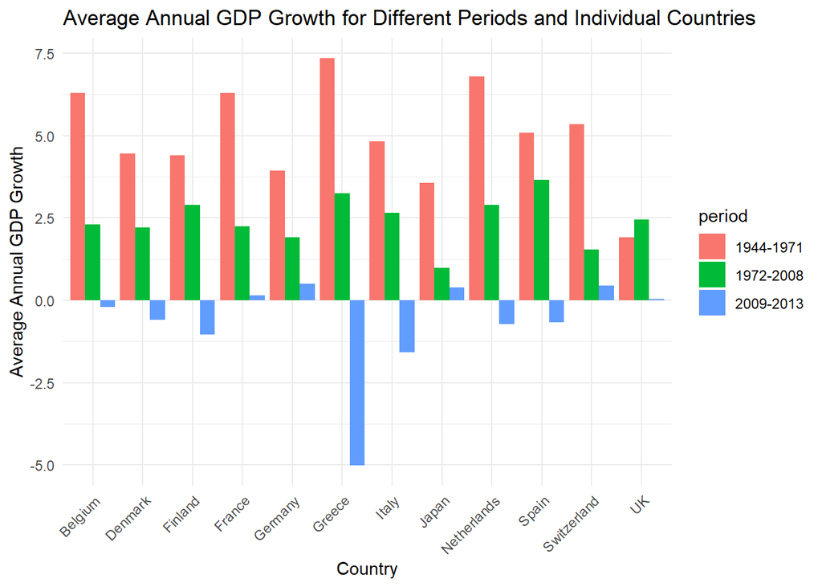

```r
# Graph for average annual growth rates by country.
ggplot(avg_growth_by_countries_combined, aes(x = country, y = avg_change, fill = period)) +
  geom_bar(stat = "identity", position = "dodge") +
  labs(title = "Average Annual GDP Growth for Different Periods and Individual Countries",
       y = "Average Annual GDP Growth",
       x = "Country") +
  theme_minimal() +
  theme(axis.text.x = element_text(angle = 45, hjust = 1))
```

Now let’s compare the average annual growth in these same 3 periods for all countries combined.

```r
# Average annual GDP growth for all analyzed countries combined in the years 2009-2013
avg_growth_2009_2013 <- avg_growth_by_countries_2009_2013 %>%
  summarise(avg_change = mean(avg_change, na.rm = TRUE))

# Average annual GDP growth for all analyzed countries combined in the years 1944-1971
avg_growth_1944_1971 <- avg_growth_by_countries_1944_1971 %>%
  summarise(avg_change = mean(avg_change, na.rm = TRUE))

# Average annual GDP growth for all analyzed countries combined in the years 1972-2008
avg_growth_1972_2008 <- avg_growth_by_countries_1972_2008 %>%
  summarise(avg_change = mean(avg_change, na.rm = TRUE))


# Combining results
avg_growth_by_periods <- bind_rows(
  mutate(avg_growth_1944_1971, period = "1944-1971"),
  mutate(avg_growth_1972_2008, period = "1972-2008"),
  mutate(avg_growth_2009_2013, period = "2009-2013")
)
```

Here is the graph comparing the average annual growth for the periods of interest for all countries combined.

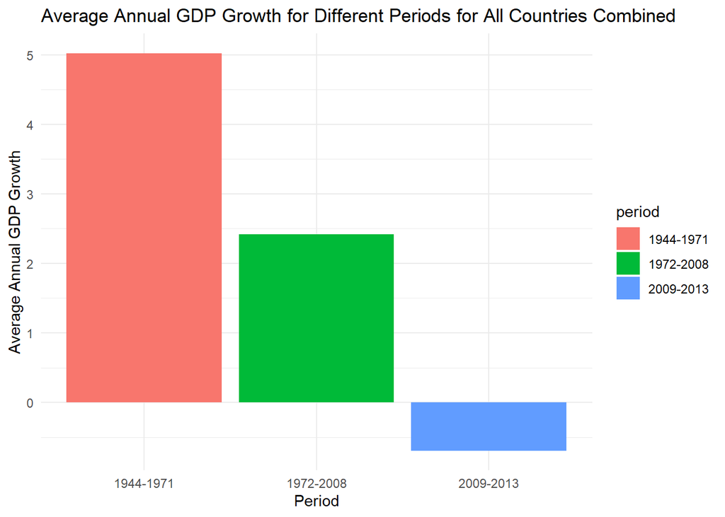

```r
# Graph for average growth rates for all countries in given periods.
ggplot(avg_growth_by_periods, aes(x = period, y = avg_change, fill = period)) +
  geom_bar(stat = "identity") +
  labs(title = "Average Annual GDP Growth for Different Periods for All Countries Combined",
       y = "Average Annual GDP Growth",
       x = "Period") +
  theme_minimal()
```

The graph shows that the average annual growth was about twice as high during the Bretton Woods system as in the years 1972-2008. It also shows that the average after the GFC saw recessions in the countries of interest.

# Investment as a % of GDP

For long-term economic growth, investment is very important, so let’s see how the share of investment in GDP developed in the countries of interest.

First, we will convert the data to the long format, as before.

```r
# Data conversion to long format
investment_analized_countries_long <- investment_analized_countries %>%
  pivot_longer(cols = -country, names_to = "Year", values_to = "Investment") %>%
  mutate(Year = as.numeric(gsub("^X", "", Year)))
```

Now we can plot a graph illustrating the share of investment in GDP over the years.

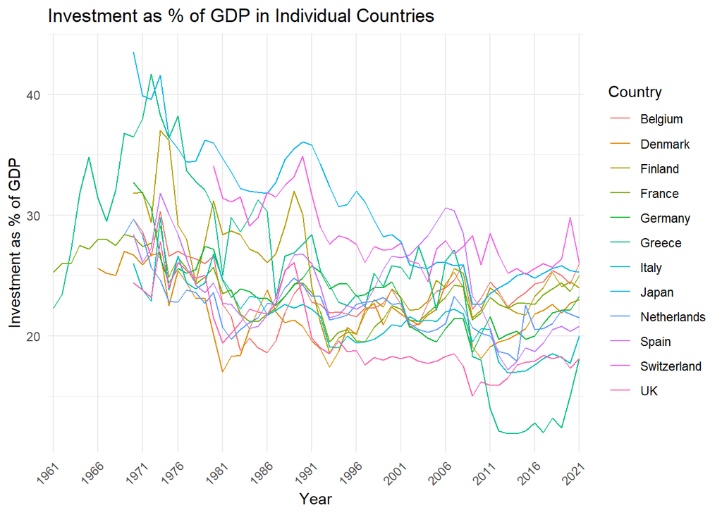

```r
# Graph of investment as % of GDP
ggplot(investment_analized_countries_long, aes(x = as.factor(Year), y = Investment, color = country, group = country)) +
  geom_line() +
  labs(title = "Investment as % of GDP in Individual Countries",
       y = "Investment as % of GDP",
       x = "Year",
       color = "Country") +
  theme_minimal() +
  theme(axis.text.x = element_text(angle = 45, hjust = 1)) +
  scale_x_discrete(breaks = seq(min(investment_analized_countries_long$Year), max(investment_analized_countries_long$Year), by = 5), labels = seq(min(investment_analized_countries_long$Year), max(investment_analized_countries_long$Year), by = 5))
```

Unfortunately, as seen in the graph, the investment data starts only from the 1960s, so we will not be able to make a full comparison of the periods of interest. However, we can calculate the average annual rate of change in the share of investment in GDP from the collapse of the Bretton Woods system to the GFC and post-crisis period to ensure that the effects of the GFC (which may have been temporary) do not affect our analysis. We will analyze the periods 1972-2005 and 2012-2021. Additionally, we will also calculate the average rate of change for the years 1972-2021.

```r
# Change in investment in 2005 compared to 1972
investment_change_2005_vs_1972_by_countries <- investment_analized_countries_long %>%
  group_by(country) %>%
  summarise(change = ((Investment[Year == 2005] / Investment[Year == 1972])^(1/(2005-1972))-1)*100)

# Change in investment in 2021 compared to 2012
investment_change_2021_vs_2012_by_countries <- investment_analized_countries_long %>%
  group_by(country) %>%
  summarise(change = ((Investment[Year == 2021] / Investment[Year == 2012])^(1/(2021-2012))-1)*100)

# Change in investment in 2021 compared to 1972
investment_change_2021_vs_1972_by_countries <- investment_analized_countries_long %>%
  group_by(country) %>%
  summarise(change = ((Investment[Year == 2021] / Investment[Year == 1972])^(1/(2021-1972))-1)*100)

# Combining results
investment_change_by_countries_combined <- bind_rows(
  mutate(investment_change_2005_vs_1972_by_countries, period = "1972-2005"),
  mutate(investment_change_2021_vs_2012_by_countries, period = "2012-2021"),
  mutate(investment_change_2021_vs_1972_by_countries, period = "1972-2021")
)
```

After calculating the average annual rates of change, we can plot them on a graph.

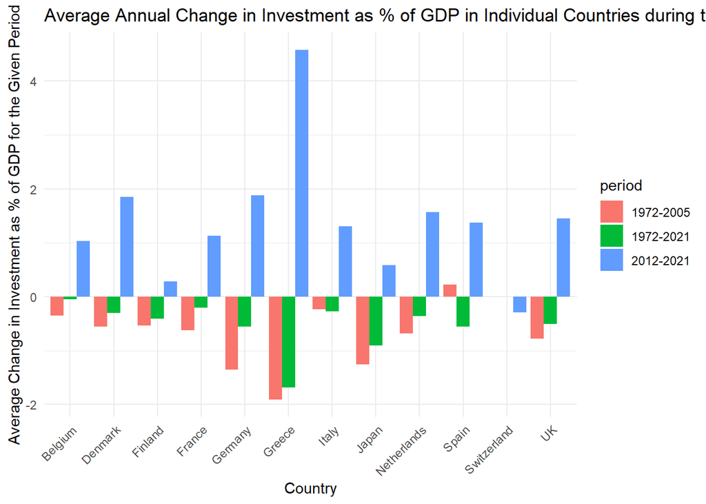

```r
# Graph
ggplot(investment_change_by_countries_combined, aes(x = country, y = change, fill = period)) +
  geom_bar(stat = "identity", position = "dodge") +
  labs(title = "Average Annual Change in Investment as % of GDP in Individual Countries during the Given Period.",
       y = "Average Change in Investment as % of GDP for the Given Period",
       x = "Country") +
  theme_minimal() +
  theme(axis.text.x = element_text(angle = 45, hjust = 1))
```

The graph shows that the share of investment in GDP in the years 1972-2005 decreased in all analyzed countries except Spain. From 2012 to 2021, we see a rebound in the share of investment in GDP after the GFC, but what is significant is that the share of investment in GDP in 2021 is lower than in 1972. Even in Germany, the average annual decrease in the share of investment in GDP was about 0.5%.

# Inflation

Some economists, however, point to the significant economic stability in the years preceding the GFC (e.g., Robert Lucas). Ben Bernanke (later Chairman of the Federal Reserve) even spoke about the “Great Moderation” a few years before the Crisis. Let’s analyze the inflation rate in the countries we are interested in.

First, convert the data to the long format.

```r
inflation_analized_countries_long <- inflation_analized_countries %>%
  pivot_longer(cols = -country, names_to = "Year", values_to = "Inflation") %>%
  mutate(Year = as.numeric(gsub("^X", "", Year)))
```

Now let’s see how inflation has developed on a graph.

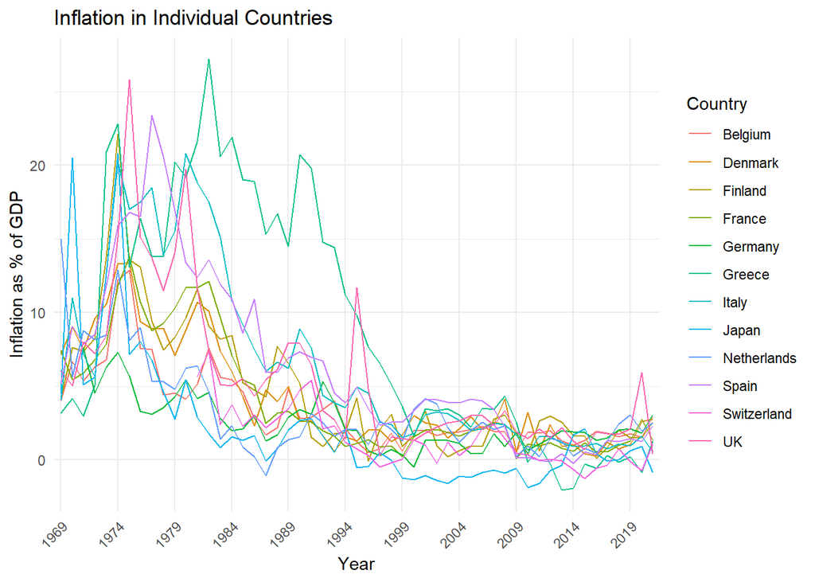

```r
# Inflation graph in individual countries
ggplot(inflation_analized_countries_long, aes(x = as.factor(Year), y = Inflation, color = country, group = country)) +
  geom_line() +
  labs(title = "Inflation in Individual Countries",
       y = "Inflation as % of GDP",
       x = "Year",
       color = "Country") +
  theme_minimal() +
  theme(axis.text.x = element_text(angle = 45, hjust = 1)) +
  scale_x_discrete(breaks = seq(min(inflation_analized_countries_long$Year), max(inflation_analized_countries_long$Year), by = 5), labels = seq(min(inflation_analized_countries_long$Year), max(inflation_analized_countries_long$Year), by = 5))
```

The graph shows that, unfortunately, like in the case of investments, our data does not cover all the years of interest. However, we can observe that after relatively high inflation rates in the 1970s and 1980s, there was a significant decrease in the 1990s and early 2000s.

To better understand this data, let’s draw boxplots for each year and place them on a timeline.

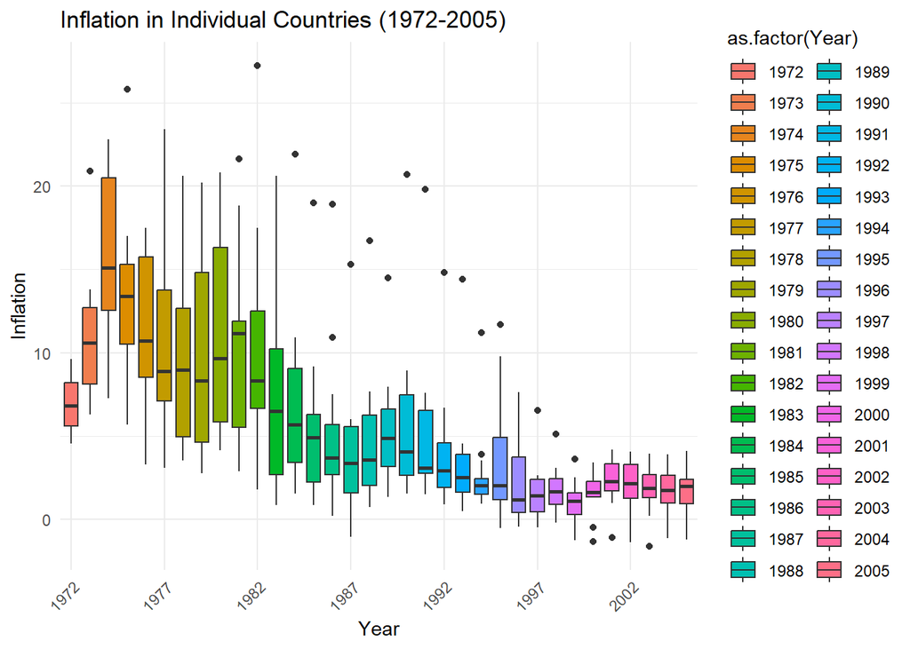

```r
# Filtering data for the period 1972-2005
inflation_analized_1972_2005 <- inflation_analized_countries_long %>%
  filter(Year >= 1972 & Year <= 2005)

# Boxplots
ggplot(inflation_analized_1972_2005, aes(x = as.factor(Year), y = Inflation, fill = as.factor(Year))) +
  geom_boxplot() +
  labs(title = "Inflation in Individual Countries (1972-2005)",
       y = "Inflation",
       x = "Year") +
  theme_minimal() +
  theme(axis.text.x = element_text(angle = 45, hjust = 1)) +
  scale_x_discrete(breaks = seq(min(inflation_analized_1972_2005$Year), max(inflation_analized_1972_2005$Year), by = 5),
                   labels = seq(min(inflation_analized_1972_2005$Year), max(inflation_analized_1972_2005$Year), by = 5))
```

Our boxplots for the years 1972-2005 show that indeed for about 20 years before the crisis, we had significant suppression of inflation. In the last few years before the Crisis, there were no outliers regarding countries with excessively high inflation; on the contrary, some of the countries we analyzed struggled with deflation.

# Trade Balance

Some economists were opposed to calling the period before the GFC the “Great Moderation” (e.g., Steve Keen). They pointed out that despite the relatively low level of inflation, there were other types of imbalances, such as a significant increase in private debt in many countries (often used for stock speculation) and significant trade imbalances.

Now we will analyze the latter, i.e., the trade balance of the countries we are interested in.

First, convert the data to the long format.

```r
trade_balance_analized_countries_long <- trade_balance_analized_countries %>%
  pivot_longer(cols = -country, names_to = "Year", values_to = "TradeBalance") %>%
  mutate(Year = as.numeric(gsub("^X", "", Year)))
```

Now we can plot a graph illustrating the trade balance of our countries over the years.

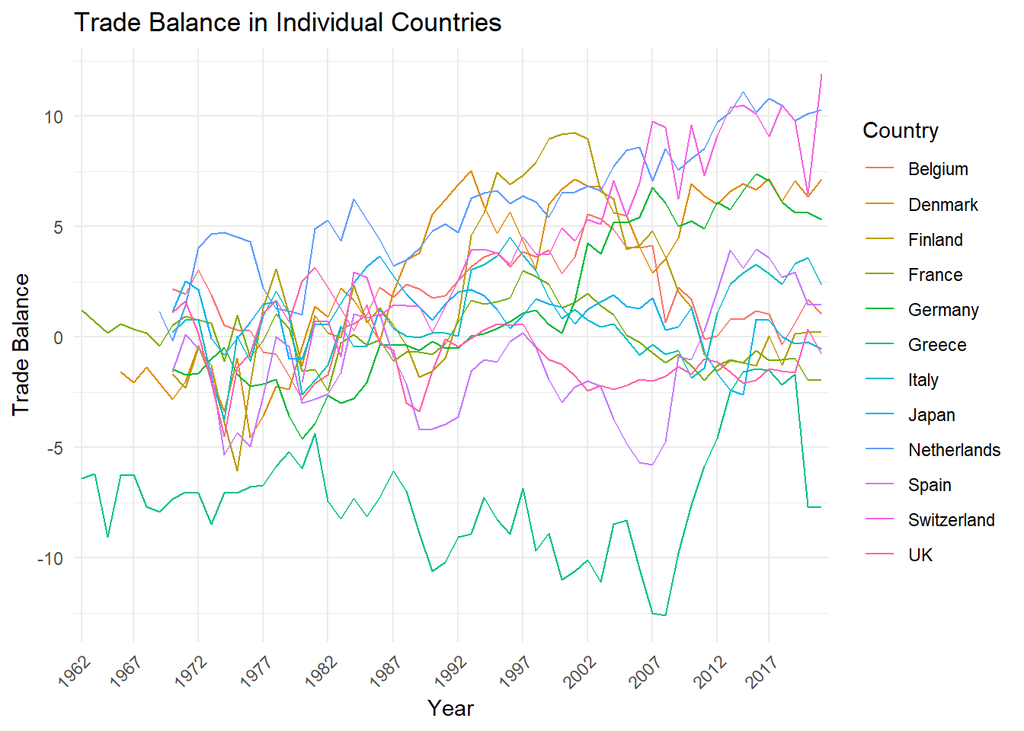

```r
# Line chart for trade balance
ggplot(trade_balance_analized_countries_long, aes(x = as.factor(Year), y = TradeBalance, color = country, group = country)) +
  geom_line() +
  labs(title = "Trade Balance in Individual Countries",
       y = "Trade Balance",
       x = "Year",
       color = "Country") +
  theme_minimal() +
  theme(axis.text.x = element_text(angle = 45, hjust = 1)) +
  scale_x_discrete(breaks = seq(min(trade_balance_analized_countries_long$Year), max(trade_balance_analized_countries_long$Year), by = 5), labels = seq(min(trade_balance_analized_countries_long$Year), max(trade_balance_analized_countries_long$Year), by = 5))
```

The graph is quite unreadable and it is difficult to draw conclusions from it, so as before, we will draw boxplots.

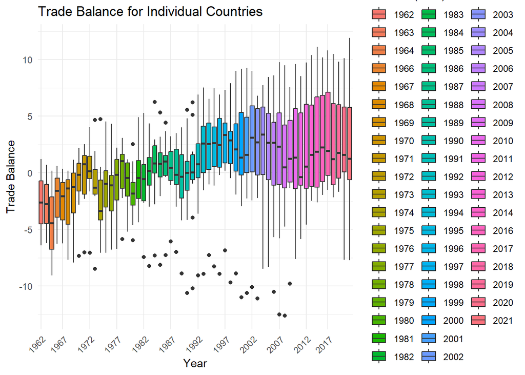

```r
# Boxplots for selected countries
ggplot(trade_balance_analized_countries_long, aes(x = as.factor(Year), y = TradeBalance, fill = as.factor(Year))) +
  geom_boxplot() +
  labs(title = "Trade Balance for Individual Countries",
       y = "Trade Balance",
       x = "Year") +
  theme_minimal() +
  theme(axis.text.x = element_text(angle = 45, hjust = 1)) +
  scale_x_discrete(breaks = seq(min(trade_balance_analized_countries_long$Year), max(trade_balance_analized_countries_long$Year), by = 5),
                   labels = seq(min(trade_balance_analized_countries_long$Year), max(trade_balance_analized_countries_long$Year), by = 5))
```

The following observations can be made from the boxplots:

- The analyzed countries have largely shifted from being deficit countries (mostly) to surplus countries (although not all) from the 1960s to today.
- Significant trade imbalances in the analyzed countries occurred a few years before the Global Financial Crisis. These imbalances remained in the few years after the crisis and then the deficits of deficit countries decreased after 2012, only to increase again in recent years.

What is important to note is that the analysis of trade balances is most reliable when considering all the countries in the world, especially those with significant surpluses or deficits, such as China or the USA, which are not included in our analysis.

# Socio-economic Indicators

Now let’s analyze some indicators at the intersection of economic and social issues, starting with the Gini coefficient.

# Gini Coefficient

The Gini coefficient tells us about income inequality in society. Its level (the higher it is, the higher the inequality) can impact not only social issues but, according to some economists, also strictly economic issues. According to them (e.g., Krugman, Stiglitz), greater inequality can lead to a decrease in aggregate demand (due to different marginal propensities to save), and thus slower economic growth.

First, as usual, let’s convert the data to long format.

```r
gini_analized_countries_long <- gini_analized_countries %>%
  pivot_longer(cols = -country, names_to = "Year", values_to = "Gini") %>%
  mutate(Year = as.numeric(gsub("^X", "", Year)))
```

Now we can analyze the average Gini coefficient for the 3 periods of interest, i.e., 1944-1971, 1972-2008, and 2009-2023.

First for each country individually.

```r
# Calculation of average Gini coefficient for the period 1944-1971
avg_gini_by_countries_1944_1971 <- gini_analized_countries_long %>%
  filter(Year >= 1944 & Year <= 1971) %>%
  group_by(country) %>%
  summarise(avg_change = mean(Gini, na.rm = TRUE))

# Calculation of average Gini coefficient for the period 1972-2008
avg_gini_by_countries_1972_2008 <- gini_analized_countries_long %>%
  filter(Year >= 1972 & Year <= 2008) %>%
  group_by(country) %>%
  summarise(avg_change = mean(Gini, na.rm = TRUE))

# Calculation of average Gini coefficient for the period 2009-2013
avg_gini_by_countries_2009_2023 <- gini_analized_countries_long %>%
  filter(Year >= 2009 & Year <= 2023) %>%
  group_by(country) %>%
  summarise(avg_change = mean(Gini, na.rm = TRUE))


# Combining results
avg_gini_by_countries_combined <- bind_rows(
  mutate(avg_gini_by_countries_1944_1971, period = "1944-1971"),
  mutate(avg_gini_by_countries_1972_2008, period = "1972-2008"),
  mutate(avg_gini_by_countries_2009_2023, period = "2009-2023")
)
```

Let’s place the calculated results on a graph.

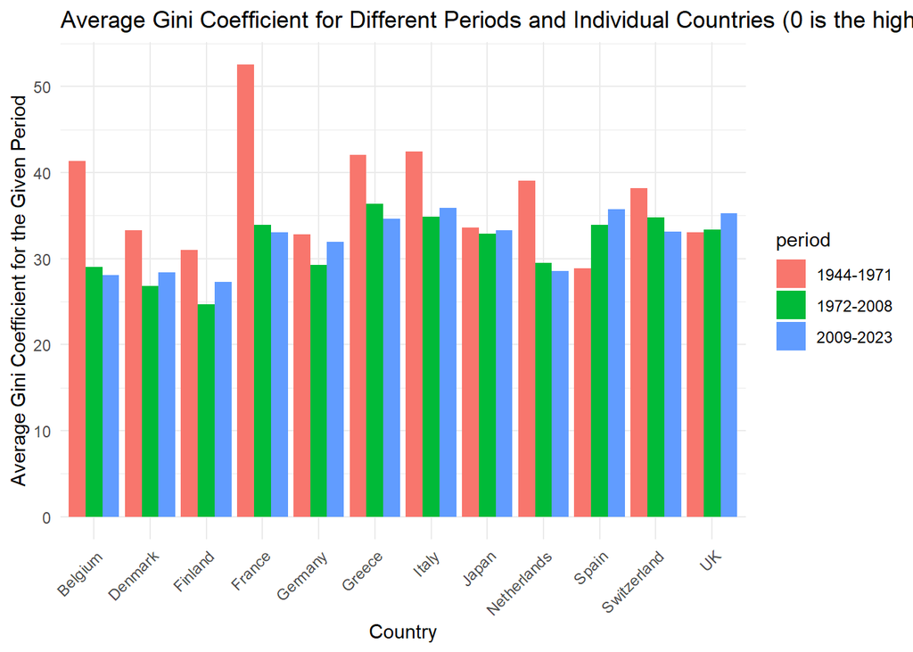

```r
ggplot(avg_gini_by_countries_combined, aes(x = country, y = avg_change, fill = period)) +
  geom_bar(stat = "identity", position = "dodge") +
  labs(title = "Average Gini Coefficient for Different Periods and Individual Countries (0 is the highest equality, 100 is the lowest equality)",
       y = "Average Gini Coefficient for the Given Period",
       x = "Country") +
  theme_minimal() +
  theme(axis.text.x = element_text(angle = 45, hjust = 1))
```

Let’s add boxplots.

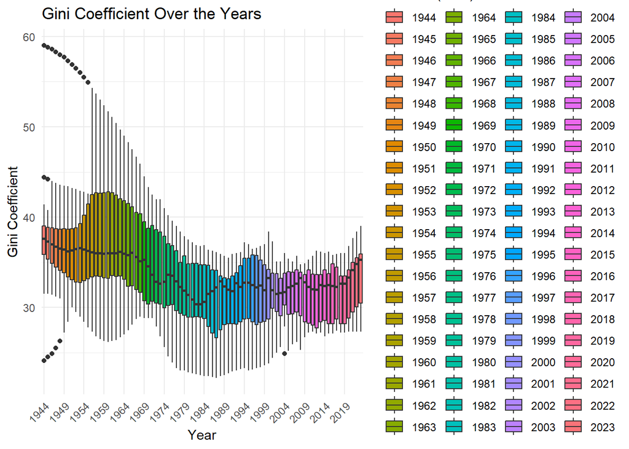

```r
# Data for the period 1944-2023
gini_analized_countries_filtered <- gini_analized_countries_long %>%
  filter(Year >= 1944 & Year <= 2023)

# Boxplot
ggplot(gini_analized_countries_filtered, aes(x = as.factor(Year), y = Gini, fill = as.factor(Year))) +
  geom_boxplot() +
  labs(title = "Gini Coefficient Over the Years",
       y = "Gini Coefficient",
       x = "Year") +
  theme_minimal() +
  theme(axis.text.x = element_text(angle = 45, hjust = 1)) +
  scale_x_discrete(breaks = seq(min(gini_analized_countries_filtered$Year), max(gini_analized_countries_filtered$Year), by = 5),
                   labels = seq(min(gini_analized_countries_filtered$Year), max(gini_analized_countries_filtered$Year), by = 5))
```

Now let’s calculate these average values for all countries combined.

```r
# Average Gini coefficient for all analyzed countries combined in the years 2009-2013
avg_gini_2009_2023 <- avg_gini_by_countries_2009_2023 %>%
  summarise(avg_change = mean(avg_change, na.rm = TRUE))

# Average Gini coefficient for all analyzed countries combined in the years 1944-1971
avg_gini_1944_1971 <- avg_gini_by_countries_1944_1971 %>%
  summarise(avg_change = mean(avg_change, na.rm = TRUE))

# Average Gini coefficient for all analyzed countries combined in the years 1972-2008
avg_gini_1972_2008 <- avg_gini_by_countries_1972_2008 %>%
  summarise(avg_change = mean(avg_change, na.rm = TRUE))


# Combining results
avg_gini_by_periods <- bind_rows(
  mutate(avg_gini_1944_1971, period = "1944-1971"),
  mutate(avg_gini_1972_2008, period = "1972-2008"),
  mutate(avg_gini_2009_2023, period = "2009-2023")
)
```

Let’s place the results on a graph.

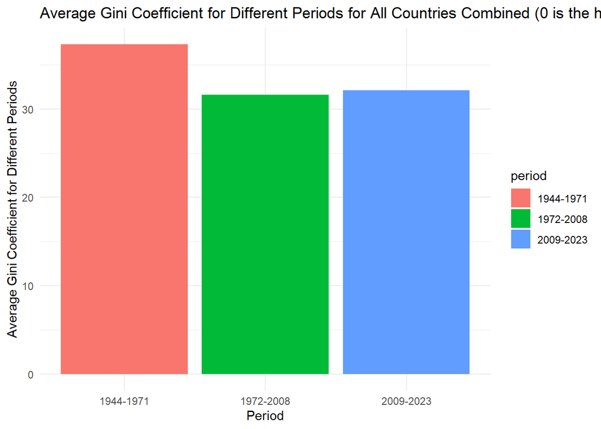

```r
# Graph for the average Gini coefficient for all countries in given periods.
ggplot(avg_gini_by_periods, aes(x = period, y = avg_change, fill = period)) +
  geom_bar(stat = "identity") +
  labs(title = "Average Gini Coefficient for Different Periods for All Countries Combined (0 is the highest equality, 100 is the lowest equality)",
       y = "Average Gini Coefficient for Different Periods",
       x = "Period") +
  theme_minimal()
```

# Unemployment

Another indicator of interest to various social sciences is the unemployment rate. Unemployment primarily affects the people involved, but it is also detrimental to society as a whole, as it indicates underutilization of so-called productive factors.

Let’s convert the data to the long format.

```r
aged_15plus_unemployment_analized_countries_long <- aged_15plus_unemployment_analized_countries %>%
  pivot_longer(cols = -country, names_to = "Year", values_to = "Unemployment") %>%
  mutate(Year = as.numeric(gsub("^X", "", Year)))
```

Let’s see the unemployment rate in the countries of interest on a graph.

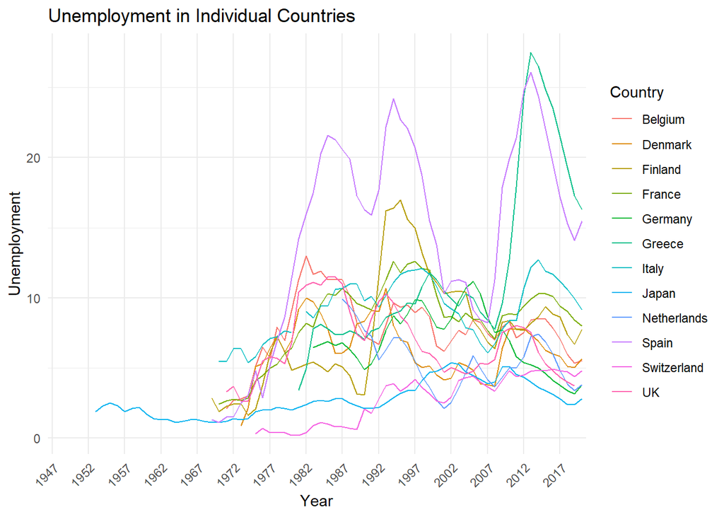

```r
# Line chart for unemployment
ggplot(aged_15plus_unemployment_analized_countries_long, aes(x = as.factor(Year), y = Unemployment, color = country, group = country)) +
  geom_line() +
  labs(title = "Unemployment in Individual Countries",
       y = "Unemployment",
       x = "Year",
       color = "Country") +
  theme_minimal() +
  theme(axis.text.x = element_text(angle = 45, hjust = 1)) +
  scale_x_discrete(breaks = seq(min(aged_15plus_unemployment_analized_countries_long$Year), max(aged_15plus_unemployment_analized_countries_long$Year), by = 5), labels = seq(min(aged_15plus_unemployment_analized_countries_long$Year), max(aged_15plus_unemployment_analized_countries_long$Year), by = 5))
```

Now let’s illustrate this data using boxplots.

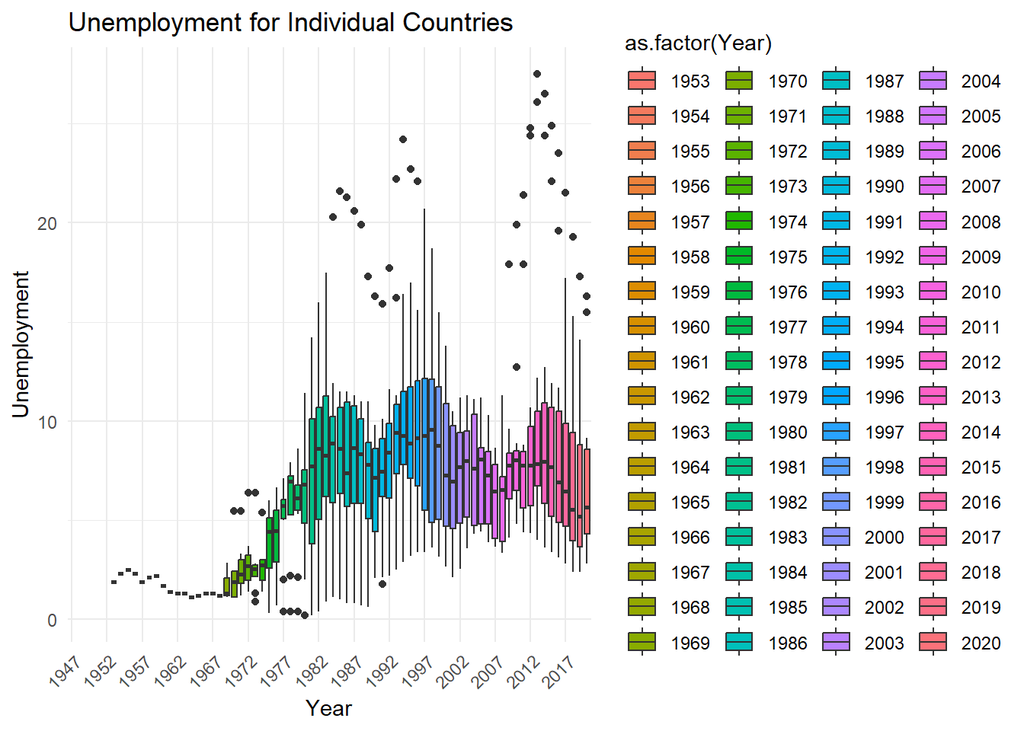

```r
# Boxplots for selected countries
ggplot(aged_15plus_unemployment_analized_countries_long, aes(x = as.factor(Year), y = Unemployment, fill = as.factor(Year))) +
  geom_boxplot() +
  labs(title = "Unemployment for Individual Countries",
       y = "Unemployment",
       x = "Year") +
  theme_minimal() +
  theme(axis.text.x = element_text(angle = 45, hjust = 1)) +
  scale_x_discrete(breaks = seq(min(aged_15plus_unemployment_analized_countries_long$Year), max(aged_15plus_unemployment_analized_countries_long$Year), by = 5),
                   labels = seq(min(aged_15plus_unemployment_analized_countries_long$Year), max(aged_15plus_unemployment_analized_countries_long$Year), by = 5))
```

Unfortunately, we have incomplete data on the period before 1971, but we can see a certain upward trend in unemployment during the 1970s. Then, over the following decades, unemployment in most countries remained between 5 and 10%, although in some countries it was between 10-20%, significantly higher than what could be considered a natural unemployment rate.

# Number of Hours Worked per Week

Unemployment is one issue, and another is how much people with jobs need to work to produce the GDP of a given country. Let’s look at the number of hours worked per week in the countries of interest.

Convert the data to the long format.

```r
working_hours_analized_countries_long <- working_hours_analized_countries %>%
  pivot_longer(cols = -country, names_to = "Year", values_to = "WorkingHours") %>%
  mutate(Year = as.numeric(gsub("^X", "", Year)))
```

Let’s plot a graph illustrating the number of hours worked per week over the years.

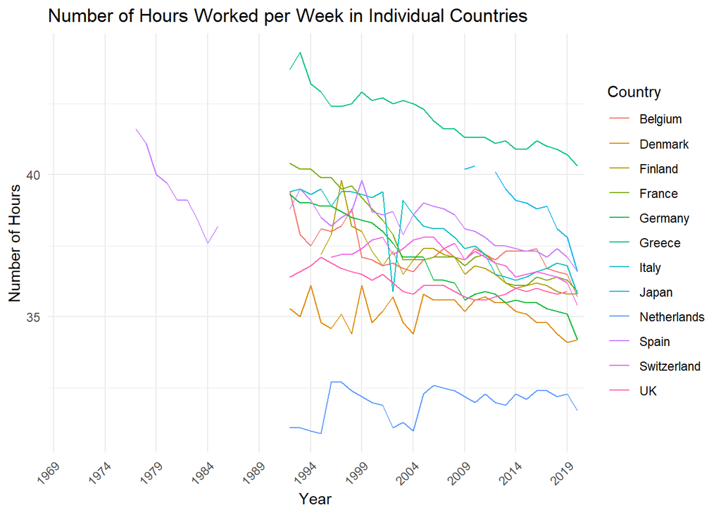

```r
# Line chart for the number of hours worked per week
ggplot(working_hours_analized_countries_long, aes(x = as.factor(Year), y = WorkingHours, color = country, group = country)) +
  geom_line() +
  labs(title = "Number of Hours Worked per Week in Individual Countries",
       y = "Number of Hours",
       x = "Year",
       color = "Country") +
  theme_minimal() +
  theme(axis.text.x = element_text(angle = 45, hjust = 1)) +
  scale_x_discrete(breaks = seq(min(working_hours_analized_countries_long$Year), max(working_hours_analized_countries_long$Year), by = 5), labels = seq(min(working_hours_analized_countries_long$Year), max(working_hours_analized_countries_long$Year), by = 5))
```

As seen in the graph, we are dealing with data of a particularly narrow range of available data, as for most countries it starts in the early 1990s.

Now let’s calculate the average annual rate of change in the number of hours worked from 1992 to 2019 and plot it on a graph.

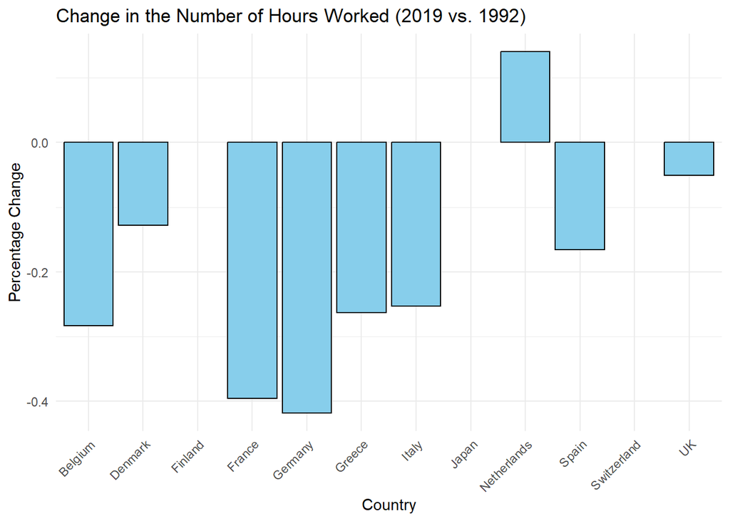

```r
# Change in the number of hours worked per week in 2019 compared to 1992
working_hours_2019_vs_1992_by_countries <- working_hours_analized_countries_long %>%
  group_by(country) %>%
  summarise(change = ((WorkingHours[Year == 2019] / WorkingHours[Year == 1992])^(1/(2019-1992))-1)*100)

# Graph of the change in the number of hours worked (2019 vs. 1992)
ggplot(working_hours_2019_vs_1992_by_countries, aes(x = country, y = change)) +
  geom_bar(stat = "identity", fill = "skyblue", color = "black") +
  labs(title = "Change in the Number of Hours Worked (2019 vs. 1992)",
       y = "Percentage Change",
       x = "Country") +
  theme_minimal() +
  theme(axis.text.x = element_text(angle = 45, hjust = 1))
```

From the resulting graph, we see that in all countries (except the Netherlands), there has been a decrease in the number of hours worked. The largest decreases, around 0.4% per year, were in France and Germany.

# Life Expectancy

Finally, let’s analyze the data on life expectancy.

Convert the data to the long format.

```r
life_expectancy_analized_countries_long <- life_expectancy_analized_countries %>%
  pivot_longer(cols = -country, names_to = "Year", values_to = "LifeExp") %>%
  mutate(Year = as.numeric(gsub("^X", "", Year)))
```

Let’s plot a graph illustrating the estimated life expectancy from 1900 to 2023.

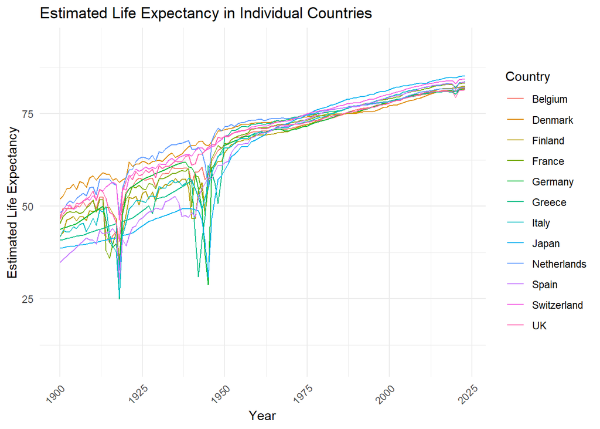

```r
# Life expectancy graph from 1900 to 2023
ggplot(life_expectancy_analized_countries_long, aes(x = Year, y = LifeExp, color = country)) +
  geom_line() +
  labs(title = "Estimated Life Expectancy in Individual Countries",
       y = "Estimated Life Expectancy",
       x = "Year",
       color = "Country") +
  theme_minimal() +
  theme(axis.text.x = element_text(angle = 45, hjust = 1)) +
  xlim(1900, 2023)
```

Now let’s calculate the average life expectancy for 3 periods: 1944-1971, 1972-2008, 2009-2023, for each country separately and plot it on a graph.

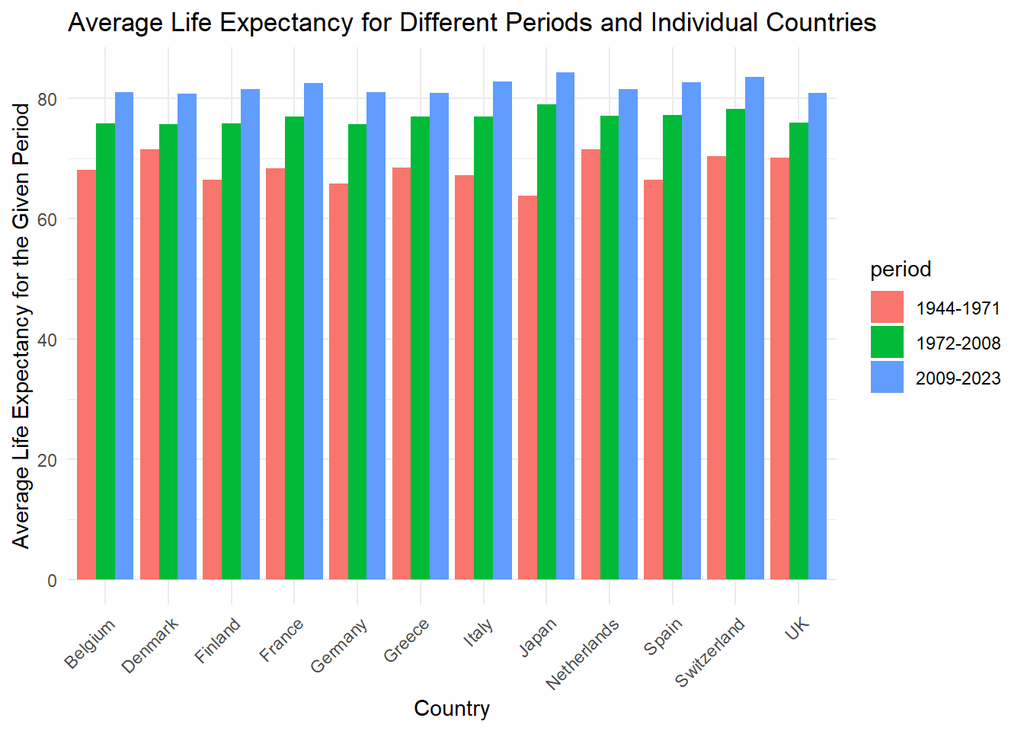

```r
# Calculation of average life expectancy for the period 1944-1971
avg_lifeExp_by_countries_1944_1971 <- life_expectancy_analized_countries_long %>%
  filter(Year >= 1944 & Year <= 1971) %>%
  group_by(country) %>%
  summarise(avg_change = mean(LifeExp, na.rm = TRUE))

# Calculation of average life expectancy for the period 1972-2008
avg_lifeExp_by_countries_1972_2008 <- life_expectancy_analized_countries_long %>%
  filter(Year >= 1972 & Year <= 2008) %>%
  group_by(country) %>%
  summarise(avg_change = mean(LifeExp, na.rm = TRUE))

# Calculation of average life expectancy for the period 2009-2023
avg_lifeExp_by_countries_2009_2023 <- life_expectancy_analized_countries_long %>%
  filter(Year >= 2009 & Year <= 2023) %>%
  group_by(country) %>%
  summarise(avg_change = mean(LifeExp, na.rm = TRUE))

# Combining results
avg_lifeExp_by_countries_combined <- bind_rows(
  mutate(avg_lifeExp_by_countries_1944_1971, period = "1944-1971"),
  mutate(avg_lifeExp_by_countries_1972_2008, period = "1972-2008"),
  mutate(avg_lifeExp_by_countries_2009_2023, period = "2009-2023")
)

# Graph for average life expectancy by country.
ggplot(avg_lifeExp_by_countries_combined, aes(x = country, y = avg_change, fill = period)) +
  geom_bar(stat = "identity", position = "dodge") +
  labs(title = "Average Life Expectancy for Different Periods and Individual Countries",
       y = "Average Life Expectancy for the Given Period",
       x = "Country") +
  theme_minimal() +
  theme(axis.text.x = element_text(angle = 45, hjust = 1))
```

Now let’s calculate the average life expectancy for 3 periods: 1944-1971, 1972-2008, 2009-2023, for all countries combined and plot it on a graph.

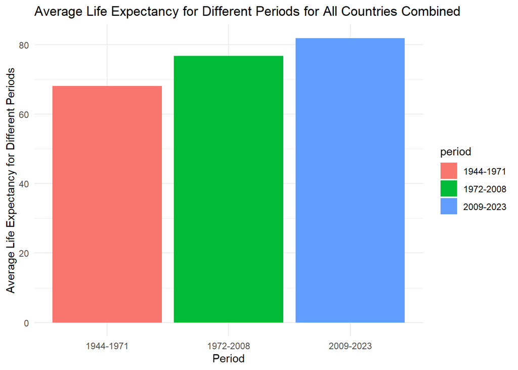

```r
# Average life expectancy for all analyzed countries combined in the years 2009-2023
avg_lifeExp_2009_2023 <- avg_lifeExp_by_countries_2009_2023 %>%
  summarise(avg_change = mean(avg_change, na.rm = TRUE))

# Average life expectancy for all analyzed countries combined in the years 1944-1971
avg_lifeExp_1944_1971 <- avg_lifeExp_by_countries_1944_1971 %>%
  summarise(avg_change = mean(avg_change, na.rm = TRUE))

# Average life expectancy for all analyzed countries combined in the years 1972-2008
avg_lifeExp_1972_2008 <- avg_lifeExp_by_countries_1972_2008 %>%
  summarise(avg_change = mean(avg_change, na.rm = TRUE))

# Combining results
avg_lifeExp_by_periods <- bind_rows(
  mutate(avg_lifeExp_1944_1971, period = "1944-1971"),
  mutate(avg_lifeExp_1972_2008, period = "1972-2008"),
  mutate(avg_lifeExp_2009_2023, period = "2009-2023")
)

# Graph for the average life expectancy for all countries in given periods.
ggplot(avg_lifeExp_by_periods, aes(x = period, y = avg_change, fill = period)) +
  geom_bar(stat = "identity") +
  labs(title = "Average Life Expectancy for Different Periods for All Countries Combined",
       y = "Average Life Expectancy for Different Periods",
       x = "Period") +
  theme_minimal()
```

Now let’s see how the expected life expectancy grew each year (within each of the 3 periods). The first period in this case will start in 1950 to eliminate the impact of World War II on life expectancy.

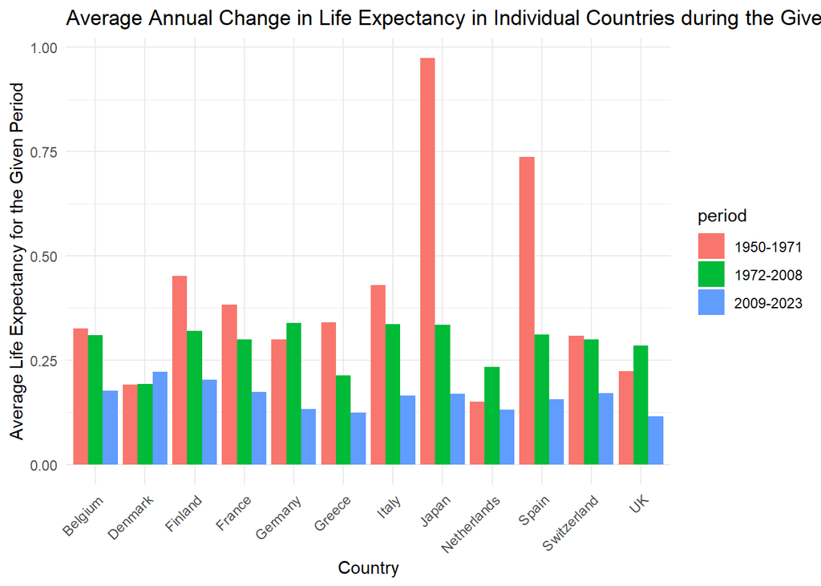

```r
# Change in life expectancy in 1971 compared to 1950
meanlifeExp_change_1971_vs_1950_by_countries <- life_expectancy_analized_countries_long %>%
  group_by(country) %>%
  summarise(change = ((LifeExp[Year == 1971] / LifeExp[Year == 1950])^(1/(1971-1950))-1)*100)

# Change in life expectancy in 2008 compared to 1972
meanlifeExp_change_2008_vs_1972_by_countries <- life_expectancy_analized_countries_long %>%
  group_by(country) %>%
  summarise(change = ((LifeExp[Year == 2008] / LifeExp[Year == 1972])^(1/(2008-1972))-1)*100)

# Change in life expectancy in 2023 compared to 2009
meanlifeExp_change_2023_vs_2009_by_countries <- life_expectancy_analized_countries_long %>%
  group_by(country) %>%
  summarise(change = ((LifeExp[Year == 2023] / LifeExp[Year == 2009])^(1/(2023-2009))-1)*100)

# Combining results
meanlifeExp_change_by_countries_combined <- bind_rows(
  mutate(meanlifeExp_change_1971_vs_1950_by_countries, period = "1950-1971"),
  mutate(meanlifeExp_change_2008_vs_1972_by_countries, period = "1972-2008"),
  mutate(meanlifeExp_change_2023_vs_2009_by_countries, period = "2009-2023")
)

# Graph for average annual change in life expectancy in individual countries during the given period.
ggplot(meanlifeExp_change_by_countries_combined, aes(x = country, y = change, fill = period)) +
  geom_bar(stat = "identity", position = "dodge") +
  labs(title = "Average Annual Change in Life Expectancy in Individual Countries during the Given Period.",
       y = "Average Life Expectancy for the Given Period",
       x = "Country") +
  theme_minimal() +
  theme(axis.text.x = element_text(angle = 45, hjust = 1))
```

Finally, let’s calculate the same for all countries combined and plot it on a graph.

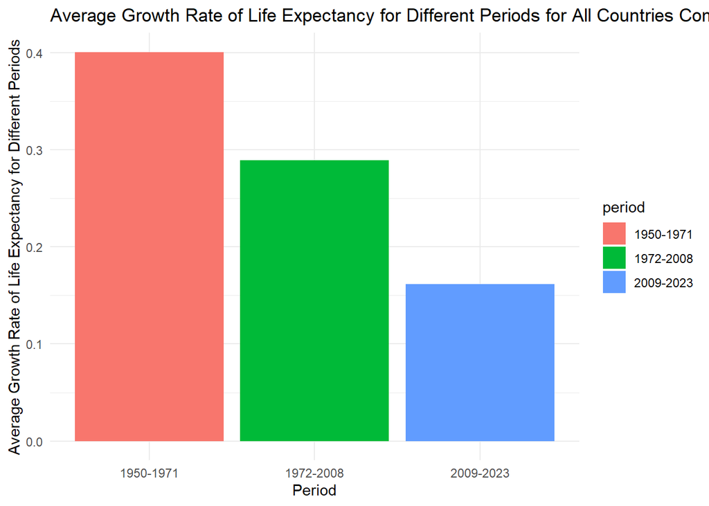

```r
# Average annual change in life expectancy for all analyzed countries combined in the years 1944-1971
meanlifeExp_change_1971_vs_1950 <- meanlifeExp_change_1971_vs_1950_by_countries %>%
  summarise(avg_change = mean(change, na.rm = TRUE))

# Average annual change in life expectancy for all analyzed countries combined in the years 1972-2008
meanlifeExp_change_2008_vs_1972 <- meanlifeExp_change_2008_vs_1972_by_countries %>%
  summarise(avg_change = mean(change, na.rm = TRUE))

# Average annual change in life expectancy for all analyzed countries combined in the years 2008-2023
meanlifeExp_change_2023_vs_2009 <- meanlifeExp_change_2023_vs_2009_by_countries %>%
  summarise(avg_change = mean(change, na.rm = TRUE))

# Combining results
meanlifeExp_change_combined <- bind_rows(
  mutate(meanlifeExp_change_1971_vs_1950, period = "1950-1971"),
  mutate(meanlifeExp_change_2008_vs_1972, period = "1972-2008"),
  mutate(meanlifeExp_change_2023_vs_2009, period = "2009-2023")
)

# Graph for average growth rates for all countries in given periods.
ggplot(meanlifeExp_change_combined, aes(x = period, y = avg_change, fill = period)) +
  geom_bar(stat = "identity") +
  labs(title = "Average Growth Rate of Life Expectancy for Different Periods for All Countries Combined",
       y = "Average Growth Rate of Life Expectancy for Different Periods",
       x = "Period") +
  theme_minimal()
```

Based on the four graphs above, we can make the following observations:

- With each subsequent period, the expected life expectancy increased.
- The highest annual increase in life expectancy was in the period 1950-1971, although there are countries (e.g., Germany, the United Kingdom) where higher annual increases were in the period 1972-2008.
- Life expectancy increased almost linearly from the beginning of the 20th century, except for the periods of World War I and World War II.

What needs to be remembered is that life expectancy can indicate economic well-being, but not fully (e.g., one accidental discovery in medicine can significantly increase it). Therefore, based on the obtained results, it is difficult to draw definite conclusions.

# Summary

Based on the above analyses, the thesis that for the analyzed countries, it was more beneficial to function during the Bretton Woods system appears more convincing. The main argument here is the year-on-year economic growth rate and the share of investment in GDP, as well as, to some extent (though incomplete) data on unemployment.

However, the Bretton Woods system ended in the early 1970s, characterized by a relatively high level of inflation, which was significantly lower in subsequent decades of the post-Bretton Woods system.

To make definitive and decisive judgments about which system was more beneficial, it would probably be necessary to conduct a much broader analysis, i.e., covering all countries in the world and using an even wider range of economic indicators.